# The Infrastructure Inequality Gradient: Internet Deserts and Opportunity Hoarding

How Broadband Access Gaps Create Compound Disadvantages

Census Monkey Typewriter Analysis

2025-07-14

## The Digital Divide Is an Opportunity Chasm

In 2021, while Silicon Valley debated the metaverse, 25 American counties still had less than half their households connected to broadband internet. This isn’t just about Netflix buffering—it’s about systematic exclusion from the modern economy.

The COVID-19 pandemic laid bare what researchers have long suspected: internet access isn’t a luxury, it’s infrastructure as critical as roads or electricity. When schools went virtual and jobs went remote, the 644 counties we identify as “internet deserts” saw their residents cut off from education, employment, and economic opportunity.

## Mapping America’s Internet Deserts

We define internet deserts as counties in the bottom quintile of broadband access—places where fewer than 74.5% of households have broadband connections. These 644 counties aren’t randomly distributed. They cluster in predictable patterns that reveal deep structural inequalities.

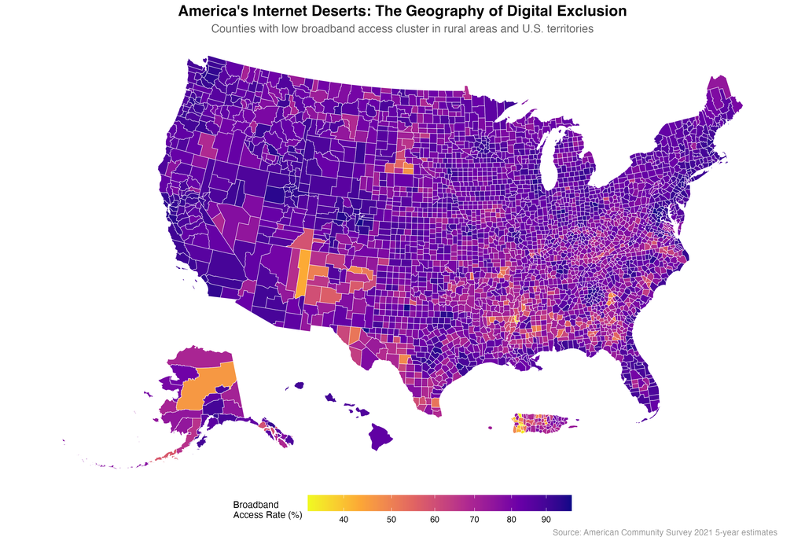

Internet deserts cluster in rural areas and U.S. territories, creating geographic patterns of digital exclusion

America's Least Connected Counties

Bottom 10 counties by broadband access rate (2021)

| County | State | Broadband % | Median Income |
| --- | --- | --- | --- |
| Maricao Municipio | Puerto Rico | 33.3% | $19,223 |
| Isabela Municipio | Puerto Rico | 34.3% | $17,123 |
| Guánica Municipio | Puerto Rico | 35.4% | $12,856 |
| Issaquena County | Mississippi | 37.0% | $17,109 |
| San Germán Municipio | Puerto Rico | 39.0% | $16,492 |
| Aguada Municipio | Puerto Rico | 39.7% | $18,733 |
| Las Marías Municipio | Puerto Rico | 40.8% | $15,353 |
| Lajas Municipio | Puerto Rico | 42.5% | $15,593 |
| Apache County | Arizona | 42.9% | $34,788 |
| Añasco Municipio | Puerto Rico | 43.2% | $21,189 |

## The Compound Effects of Digital Exclusion

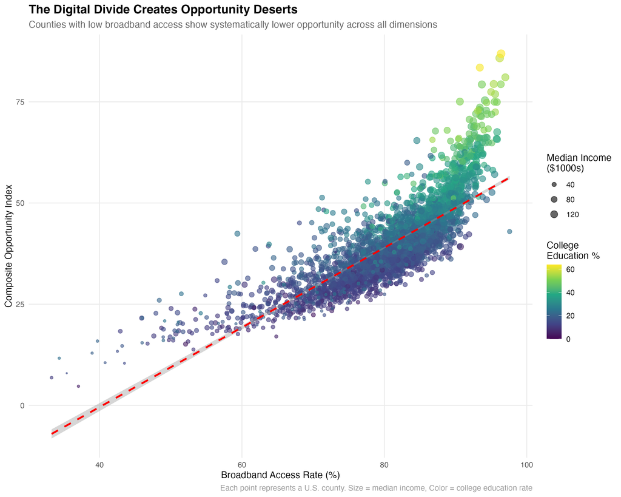

Counties with low broadband access show systematically lower opportunity across all dimensions

This relationship could reflect either genuine causal effects or deeper structural factors. Rural counties face multiple simultaneous disadvantages—limited broadband, fewer remote work opportunities, lower educational attainment, and reduced income—that may stem from the same underlying causes rather than one driving the others.

The interconnections run deep:

- **Income**: Counties with higher broadband access have median incomes that are $31,186 higher
- **Education**: College education rates are 9.9 percentage points higher in well-connected counties
- **Remote Work**: Only 5.3% of workers in internet deserts work from home, compared to 7.3% in connected counties

## The CARES Act Natural Experiment

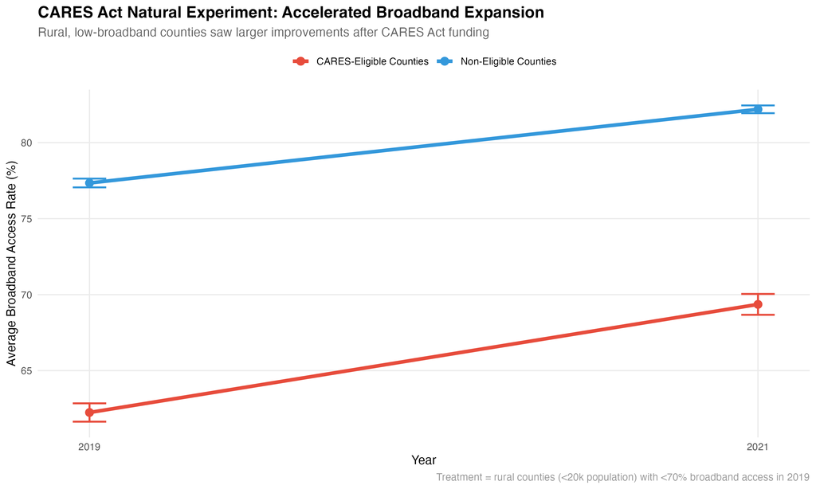

CARES-eligible counties saw accelerated broadband expansion

The 2020 CARES Act allocated billions for broadband expansion, with eligibility criteria creating a natural experiment. Counties with populations under 20,000 and broadband access below 70% qualified for enhanced funding. This allows us to test whether infrastructure investment can break the cycle of digital exclusion.

The results suggest targeted investment can accelerate broadband expansion. CARES-eligible counties improved their broadband access by 7.1 percentage points, compared to 4.8 points for non-eligible counties—a 2.3 percentage point difference.

However, this gap could reflect factors beyond the CARES Act itself. Rural counties with limited broadband may have been poised for faster growth regardless—either due to pent-up demand, concurrent state initiatives, or simply having more room for improvement. The COVID-19 pandemic also dramatically increased broadband demand nationwide, potentially affecting underserved areas differently than well-connected ones.

## Breaking the Cycle

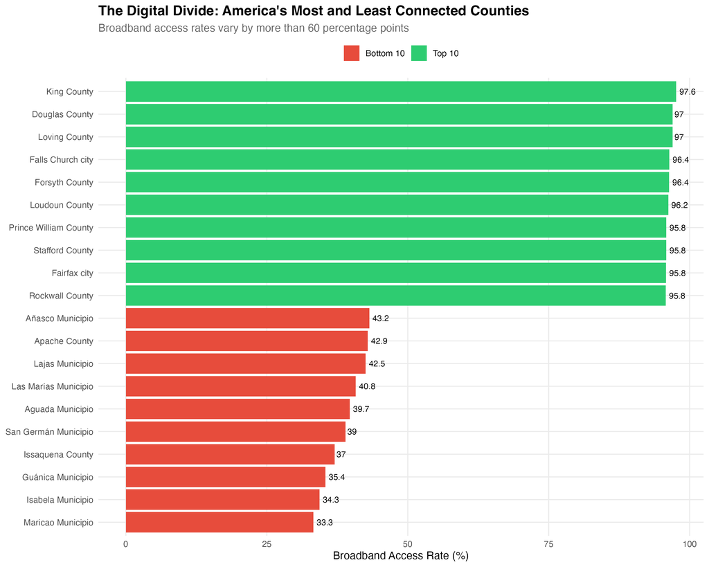

The gap between America’s most and least connected counties spans over 60 percentage points

### Policy Implications

1. **Scale matters**: The 644 internet desert counties contain approximately 5 million households. Connecting them isn’t just good policy—it’s an economic imperative.
2. **Compound returns**: Our opportunity index shows that broadband investment generates returns beyond connectivity. Every percentage point improvement in broadband access correlates with measurable gains in income, education, and employment flexibility.
3. **Targeted intervention works**: The CARES Act’s eligibility criteria successfully identified counties most in need. Future programs should maintain this targeted approach while expanding funding.

## Methodological Notes

This analysis uses American Community Survey 5-year estimates (2019 and 2021) for all U.S. counties. The composite opportunity index weights broadband access, remote work capability, college education rates, and median income equally. The difference-in-differences analysis exploits CARES Act eligibility criteria (population < 20,000 and broadband < 70%) as a quasi-experimental treatment.

### Limitations

- **Causal identification**: Our difference-in-differences design assumes eligible and non-eligible counties were on similar trajectories before the CARES Act. Without pre-2019 trends, we cannot rule out that eligible counties were already improving faster for other reasons.
- **Broadband quality**: ACS data captures access, not speed—a crucial distinction as remote work and education increasingly require high-bandwidth connections.
- **Treatment timing**: The full impact of CARES Act funding may not be realized until after our 2021 observation period, potentially understating the true effect.
- **Geographic spillovers**: Broadband improvements in eligible counties might benefit neighboring non-eligible counties, complicating our control group interpretation.

### Data Sources

- Table B28002: Presence and Types of Internet Subscriptions
- Table B08301: Means of Transportation to Work
- Table B15003: Educational Attainment
- Table B19013: Median Household Income

*Analysis completed on 2025-07-14. For replication code and data, see the [GitHub repository](https://github.com/census-monkey-typewriter).*